博客

发表于 2016-09-05 |

# R语言分位回归

## 线性回归条件

我们平时常用线性回归，基本要求简写为”LINE”, 对变量的要求:

1. “L”: 是线性的 (计量资料)
2. “I”: 变量间相互独立 (不要有多重共线性)
3. “N”: 要正态分布
4. “E”: 误差独立分布

然而，现实资料中”L”和”E”条件是滿足的, 但”I”和”N”未必能满足, 为此，我们时常选择下面方法解决问题：

- “I”—岭回归, 主成分分析, 或删去多重线性的变量，取相关性最大变量;
- “N”—百分位数回归…

下面主要介绍百分位数回归，其实质是将变量分段，取任一分位数事，变量的回归系数。 优势在于：1.一定程度全面展示所有资料的信息，但更侧重于对不同分位数的人群的异质性分析 其能在一定程度上全面展示所有資料的資訊，但更側重於對特徵分佈不同位置人群的異質性分析。尤其适用于不均匀分布，且分位数回归分析较传统线性回归模型的系数估计更稳健。

## 演示R语言的操作

在此以quantreg包操作为例。以及使用quantreg包內自带数据engel示例…

### 程序包及数据准备

```r
#install.packages(“quantreg”) #安裝及使用quantreg包
library(quantreg)   #调取quantreg包
data("engel")  #使用自帶的数据engel
```

### 正态性检验

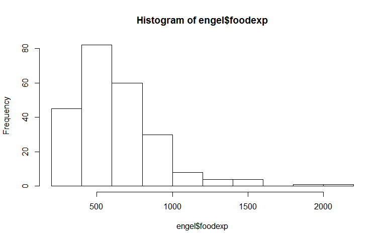

```r
foodnor = shapiro.test(engel$foodexp)  #正态性检验
foodhist = hist(engel$foodexp)  #作個频数直条图
```

### 分位数回归实践

```r
fit = rq(foodexp~income,data=engel,tau=c(0.25,0.5,0.75))  #分数数回归: 命令rq, 公式foodexp~income
summary(fit)  #汇总结果
```

```
##
## Call: rq(formula = foodexp ~ income, tau = c(0.25, 0.5, 0.75), data = engel)
##
## tau: [1] 0.25
##
## Coefficients:
##             coefficients lower bd  upper bd
## (Intercept)  95.48354     73.78608 120.09847
## income        0.47410      0.42033   0.49433
##
## Call: rq(formula = foodexp ~ income, tau = c(0.25, 0.5, 0.75), data = engel)
##
## tau: [1] 0.5
##
## Coefficients:
##             coefficients lower bd  upper bd
## (Intercept)  81.48225     53.25915 114.01156
## income        0.56018      0.48702   0.60199
##
## Call: rq(formula = foodexp ~ income, tau = c(0.25, 0.5, 0.75), data = engel)
##
## tau: [1] 0.75
##
## Coefficients:
##             coefficients lower bd  upper bd
## (Intercept)  62.39659     32.74488 107.31362
## income        0.64401      0.58016   0.69041
```

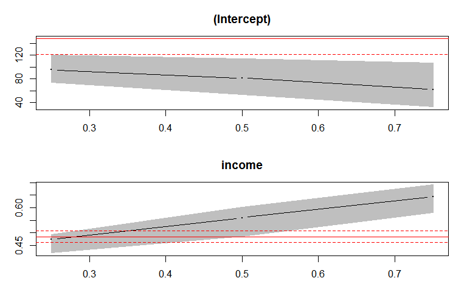

```r
plot(summary(fit))  #多结果绘图
```

### 模型验证

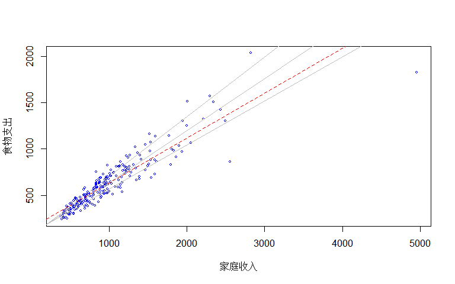

```r
plot(engel$income,engel$foodexp,cex=0.25,
     type="n", xlab="家庭收入", ylab="食物支出")


points(engel$income,engel$foodexp,cex=0.5,col="blue")  # 添加點，點的大小為0.5
abline( rq(foodexp ~ income, data =engel,tau=0.5), col="blue" )  # 中位回归结果 蓝色
abline( lm(foodexp ~ income,data =engel), lty = 2, col="red" )  # 最小二乘法 红色
taus<-c(0.25, 0.5, 0.75)
for(i in 1:length(taus)){  # 不同分为的数据，顏色为灰色
  abline( rq(foodexp ~ income,data =engel, tau=taus[i]), col="gray" )
}
```